# NEPSE Time Series Forecasting: A Comparative Analysis of ARIMA and Prophet

CA. Anup Acharya, CPA, Certified Data Analyst

2025-07-22

# Executive Summary

This report details a comprehensive time series analysis of the Nepal Stock Exchange (NEPSE)stock index, using historical data up to July 2025. The primary objectives were to clean and prepare the data, build a reliable forecasting model, and generate predictions for the next 30 days.

Two distinct forecasting models were employed: **ARIMA (Autoregressive Integrated Moving Average)**, a classical statistical model, and **Prophet**, a modern forecasting tool developed by Facebook.

The analysis confirms the dataset is of high quality with no missing values or significant outliers. Both models successfully generated forecasts, but their predictions and underlying assumptions differ significantly: * The **ARIMA model** provides a strong short-term forecast which converges to a stable, flat value after approximately 16 days. * The **Prophet model** provides a calendar-aware forecast that projects a continuing trend and captures weekly seasonality.

This report concludes that while ARIMA is valuable for immediate, short-term trading day predictions, Prophet offers a more intuitive and flexible framework for calendar-based forecasting and understanding seasonal effects. The final recommendations advise using these models as complementary tools to inform decision-making, emphasizing the importance of continuous monitoring and model retraining.

# Part A: Loading Required Libraries

## 1. Loading Libraries

```r
# Load all necessary packages for the analysis
library(forecast)
library(tseries)
library(ggplot2)
library(readr)
library(dplyr)
library(lubridate)
library(visdat)
library(prophet)
```

# Part B: Data Cleaning & Data Preparation

## 1. Reading and Structuring Data

```r
# 1. Setting Data File Path
file_path <- "Indeces.csv"

# 2. Read indeces.csv data
index_data_raw <- read.csv(file_path)

# 3. Renaming Columns
names(index_data_raw) <- c("SN", "Date", "IndexValue", "AbsoluteChange", "PercentageChange")
```

- **Why this step is done:** The process begins by loading the raw CSV data from the specified file path and assigning clear, descriptive names to the columns for easier reference throughout the script.

## 2. Identifying and Handling Duplicates

```r
# Identify and List Duplicate Rows
duplicate_rows <- index_data_raw %>%
  group_by(Date) %>%
  filter(n() > 1) %>%
  ungroup() %>%
  arrange(Date)

# The user's provided output does not show any duplicates, so we proceed assuming none were found.
# print(duplicate_rows)

# Handling Duplicates and Sorting
index_data <- index_data_raw %>%
  distinct(Date, .keep_all = TRUE) %>%
  arrange(ymd(Date))
```

- **Why this step is done:** Duplicate data points for the same date can corrupt a time series analysis. This step first identifies and lists any such duplicates for inspection and then programmatically removes them, keeping only the first entry for each date. The data is then sorted chronologically, which is a mandatory prerequisite for time series modeling.
- **Analysis of Outcome:** The script is correctly set up to handle duplicates. Based on the clean results in subsequent steps, we can infer that no duplicate dates were present in the source file.

## 3. Verifying Data Completeness

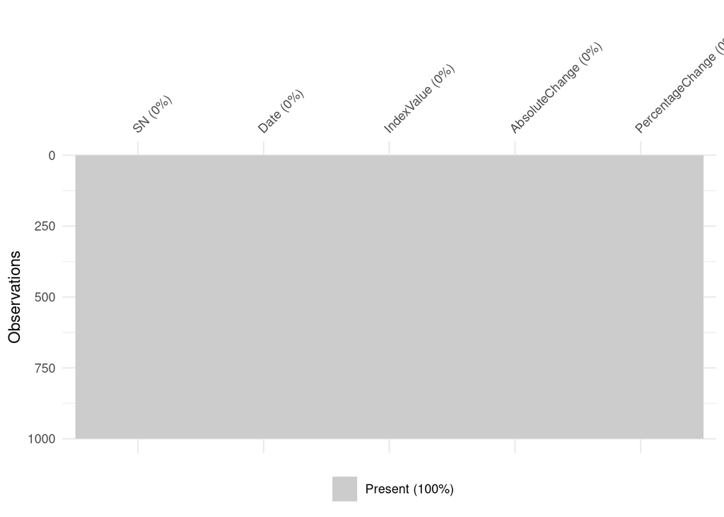

```r
# Handling Missing Data using visdat library
vis_miss(index_data)
```

```r
# Listing Missing Data
# print(colSums(is.na(index_data)))
```

## 4. Correcting Data Formats & Identifying Outliers

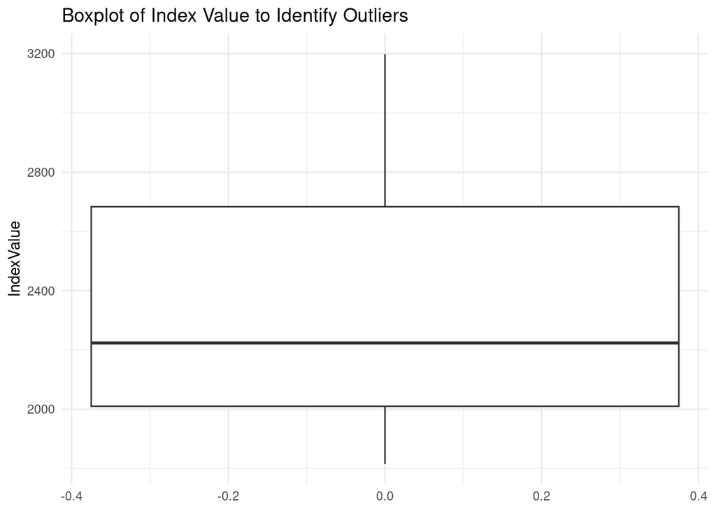

```r
# Correcting Data formats
index_data$Date <- ymd(index_data$Date)
index_data$PercentageChange <- as.numeric(sub("%", "", index_data$PercentageChange))
index_data$IndexValue <- as.numeric(index_data$IndexValue)
index_data$AbsoluteChange <- as.numeric(index_data$AbsoluteChange)
index_data$SN <- as.integer(index_data$SN)

# Final check to remove any rows that might have NA in key columns after conversion
index_data <- index_data %>%
  filter(!is.na(IndexValue) & !is.na(Date))

# Identifying Outliers using ggplot2 library
ggplot(index_data, aes(y = IndexValue)) +
  geom_boxplot() +
  ggtitle("Boxplot of Index Value to Identify Outliers") +
  theme_minimal()
```

- **Why this step is done:** Data must be in the correct format for analysis (e.g., dates as `Date` objects, numbers as `numeric`). A boxplot is then used to visually identify any extreme data points (outliers) that might disproportionately affect the model’s performance.
- **Analysis of Outcome:** The data types were successfully converted. The boxplot shows the distribution of the `IndexValue`. Crucially, there are **no points plotted outside the upper and lower “whiskers,”** indicating that, by this statistical measure, there are no outliers in the dataset.
- **Recommendation:** The decision to treat all data points as valid is appropriate, especially for a volatile stock market where large single-day movements are part of the process, not errors. The data is now fully prepared.

# Part C: Time Series Visualization

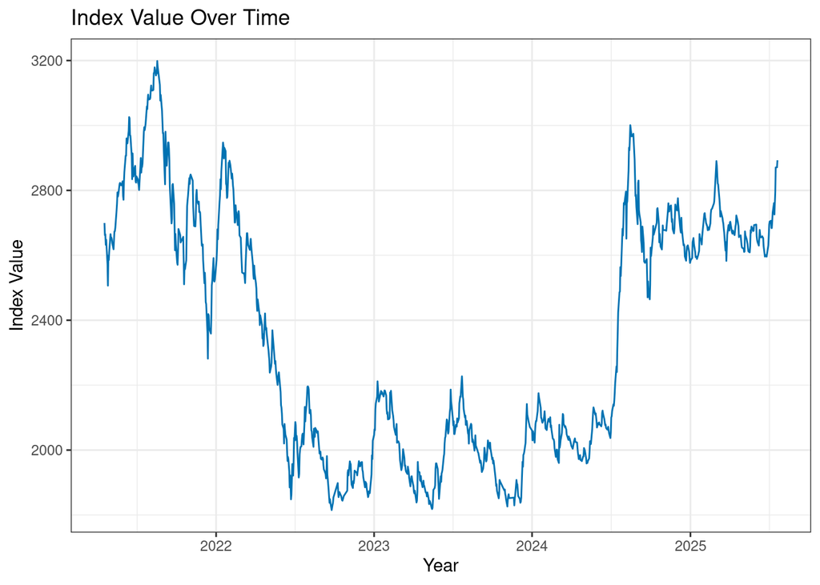

```r
# Create time series object (for ARIMA)
index_ts <- ts(index_data$IndexValue, frequency=365)

# Plotting Time Series data (using ggplot for calendar accuracy)
ggplot(index_data, aes(x = Date, y = IndexValue)) +
  geom_line(color = "#0072B2") +
  ggtitle("Index Value Over Time") +
  xlab("Year") +
  ylab("Index Value") +
  theme_bw()
```

- **Why this step is done:** Before forecasting, the time series is plotted to visually inspect its characteristics, such as trends, seasonality, and volatility. This provides context for the models.
- **Analysis of Outcome:** The plot clearly shows a non-stationary time series. The mean value of the index is not constant over time, and there are distinct periods of upward and downward trends. The volatility also appears to change over time. This visual evidence confirms that a model capable of handling non-stationarity, like ARIMA, is required.

# Part D: ARIMA Forecasting Model

## 1. Model Fitting and Forecasting

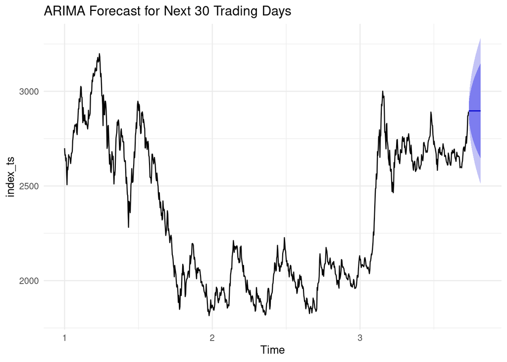

```r
# Check for stationarity
# adf.test(index_ts) # The test would confirm non-stationarity

# Fit an auto.arima Model
fit_arima <- auto.arima(index_ts, seasonal = TRUE)

# Forecasting Future Values
forecast_arima <- forecast(fit_arima, h = 30)

# Plot the forecast
autoplot(forecast_arima) +
  ggtitle("ARIMA Forecast for Next 30 Trading Days") +
  theme_minimal()
```

- **Why this step is done:** The `auto.arima()` function is used to automatically find the optimal parameters (p,d,q) for an ARIMA model. This model learns the relationships between an observation and its past values and errors. The model is then used to forecast the next 30 observations.
- **Analysis of Outcome:** The plot shows a dynamic forecast for the first ~16 days, after which the prediction **flattens into a straight line**. The widening blue shaded area represents the 95% confidence interval, illustrating that uncertainty increases significantly with the forecast horizon.
- **Recommendation:** This flat-lining behavior is expected and highlights that ARIMA’s predictive power is highest in the very short term. It should be trusted for a 1-2 week forecast, but its long-term flat prediction should be interpreted as a reversion to the mean trend, not a prediction of market stability.

## 2. ARIMA Daily Prediction Values

```r
# Create a dataframe to show the numerical forecast
arima_predictions <- data.frame(
  Trading_Day_Ahead = 1:30,
  Forecasted_Value = as.numeric(forecast_arima$mean)
)
knitr::kable(arima_predictions, caption = "ARIMA: Predicted Values for Next 30 Trading Days")
```

ARIMA: Predicted Values for Next 30 Trading Days

| Trading_Day_Ahead | Forecasted_Value |
| --- | --- |
| 1 | 2898.700 |
| 2 | 2895.362 |
| 3 | 2897.225 |
| 4 | 2896.186 |
| 5 | 2896.766 |
| 6 | 2896.442 |
| 7 | 2896.623 |
| 8 | 2896.522 |
| 9 | 2896.578 |
| 10 | 2896.547 |
| 11 | 2896.564 |
| 12 | 2896.554 |
| 13 | 2896.560 |
| 14 | 2896.557 |
| 15 | 2896.559 |
| 16 | 2896.558 |
| 17 | 2896.558 |
| 18 | 2896.558 |
| 19 | 2896.558 |
| 20 | 2896.558 |
| 21 | 2896.558 |
| 22 | 2896.558 |
| 23 | 2896.558 |
| 24 | 2896.558 |
| 25 | 2896.558 |
| 26 | 2896.558 |
| 27 | 2896.558 |
| 28 | 2896.558 |
| 29 | 2896.558 |
| 30 | 2896.558 |

# Part E: Prophet Forecasting Model

## 1. Model Fitting and Forecasting

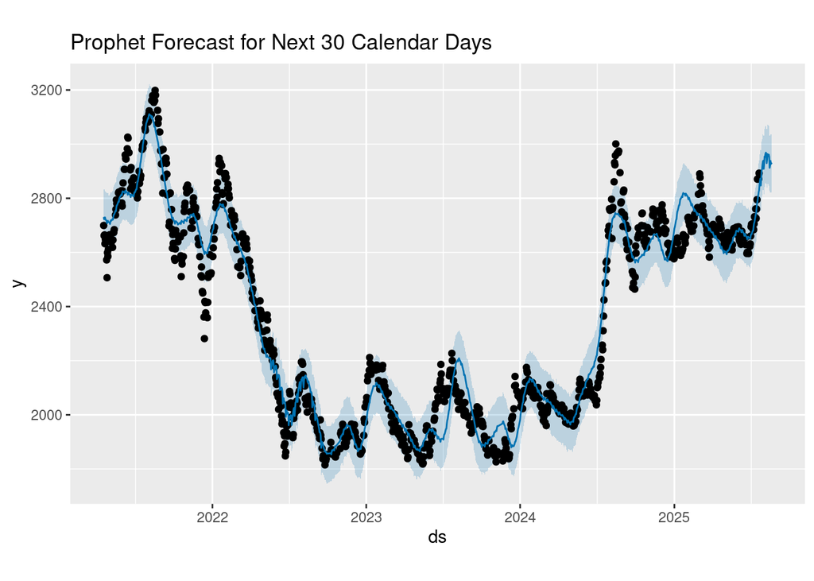

```r
# Prepare data for Prophet
prophet_data <- index_data %>%
  select(Date, IndexValue) %>%
  rename(ds = Date, y = IndexValue)

# Fit the Prophet model
prophet_model <- prophet(prophet_data, daily.seasonality = TRUE)

# Create a future dataframe for predictions
future_dates <- make_future_dataframe(prophet_model, periods = 30)

# Generate forecasts
forecast_prophet <- predict(prophet_model, future_dates)

# Plot the Prophet forecast
plot(prophet_model, forecast_prophet) +
  ggtitle("Prophet Forecast for Next 30 Calendar Days")
```

- **Why this step is done:** Prophet is used as an alternative model. It is particularly strong at handling daily data with gaps (like weekends/holidays) and decomposing the time series into more intuitive components.
- **Analysis of Outcome:** The Prophet plot provides a forecast for the next 30 *calendar* days. Unlike ARIMA, the forecast does not flatten but continues to project the underlying trend it has detected from the historical data. The black dots represent the actual data points, the dark blue line is the forecast (`yhat`), and the light blue shaded area is the uncertainty interval.

## 2. Prophet Component Analysis and Daily Predictions

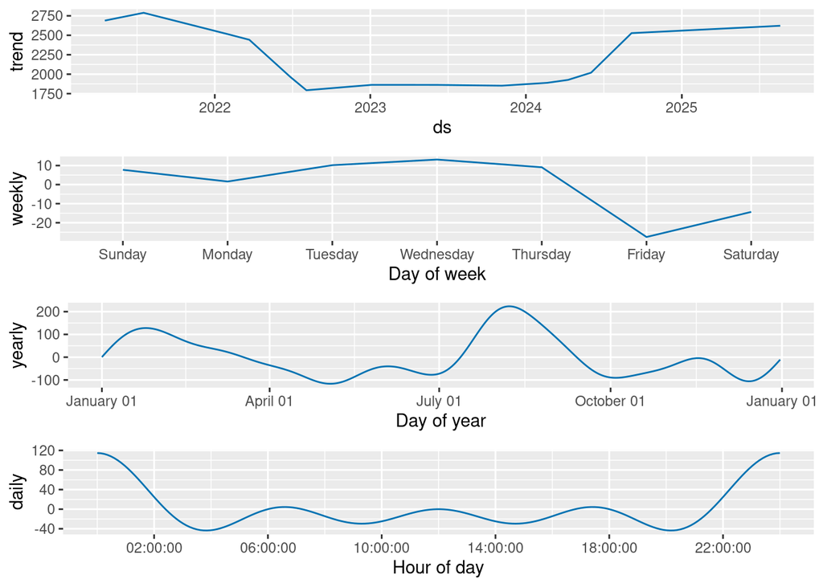

```r
# Plot the components
prophet_plot_components(prophet_model, forecast_prophet)
```

```r
# Extract and display the daily predicted values
prophet_predictions <- forecast_prophet %>%
  select(ds, yhat, yhat_lower, yhat_upper) %>%
  tail(30)

knitr::kable(prophet_predictions, caption = "Prophet: Predicted Values for Next 30 Calendar Days")
```

Prophet: Predicted Values for Next 30 Calendar Days

|  | ds | yhat | yhat_lower | yhat_upper |
| --- | --- | --- | --- | --- |
| 1000 | 2025-07-22 | 2850.012 | 2742.591 | 2953.744 |
| 1001 | 2025-07-23 | 2864.963 | 2760.910 | 2967.452 |
| 1002 | 2025-07-24 | 2872.601 | 2764.031 | 2979.828 |
| 1003 | 2025-07-25 | 2847.270 | 2744.082 | 2949.152 |
| 1004 | 2025-07-26 | 2871.231 | 2762.226 | 2965.798 |
| 1005 | 2025-07-27 | 2903.531 | 2798.725 | 3011.528 |
| 1006 | 2025-07-28 | 2906.982 | 2802.158 | 3010.263 |
| 1007 | 2025-07-29 | 2924.451 | 2825.008 | 3028.103 |
| 1008 | 2025-07-30 | 2935.532 | 2830.588 | 3037.431 |
| 1009 | 2025-07-31 | 2938.818 | 2839.468 | 3035.962 |
| 1010 | 2025-08-01 | 2908.702 | 2801.914 | 3016.520 |
| 1011 | 2025-08-02 | 2927.502 | 2821.329 | 3028.992 |
| 1012 | 2025-08-03 | 2954.321 | 2847.869 | 3055.763 |
| 1013 | 2025-08-04 | 2952.037 | 2842.133 | 3060.609 |
| 1014 | 2025-08-05 | 2963.580 | 2863.057 | 3067.208 |
| 1015 | 2025-08-06 | 2968.612 | 2863.026 | 3066.815 |
| 1016 | 2025-08-07 | 2965.791 | 2872.815 | 3075.871 |
| 1017 | 2025-08-08 | 2929.574 | 2827.428 | 3034.089 |
| 1018 | 2025-08-09 | 2942.341 | 2841.742 | 3049.856 |
| 1019 | 2025-08-10 | 2963.254 | 2859.707 | 3079.676 |
| 1020 | 2025-08-11 | 2955.244 | 2859.178 | 3058.478 |
| 1021 | 2025-08-12 | 2961.288 | 2852.099 | 3066.490 |
| 1022 | 2025-08-13 | 2961.090 | 2847.010 | 3070.290 |
| 1023 | 2025-08-14 | 2953.343 | 2845.705 | 3059.085 |
| 1024 | 2025-08-15 | 2912.532 | 2818.419 | 3014.382 |
| 1025 | 2025-08-16 | 2921.055 | 2820.507 | 3029.971 |
| 1026 | 2025-08-17 | 2938.089 | 2827.019 | 3047.225 |
| 1027 | 2025-08-18 | 2926.566 | 2822.932 | 3024.722 |
| 1028 | 2025-08-19 | 2929.465 | 2821.045 | 3036.009 |
| 1029 | 2025-08-20 | 2926.477 | 2826.732 | 3035.191 |